# Clean Code

Kaitlin Rommelfanger

2023-10-13

## Things to add

1. Set seed for nMDS
2. Paper name for why we broke apart the snapper
3. how to finalize the simper, some families are borderline significant, sometimes when you run it they are , and sometime they are not what is the protocol to make this

## Analyses

### NMDS

This first section is the nMDS looking at fish communities at the family level, we split the seagrass into three categories, the first is all transects deeper than 15 meters, this was determined to be the depth that native seagrasses stop growing

We split the seagrass shallower than 15m into two categories 1, where all seagrass present was halophila (<15m,100% halophila), and one where there was native seagrasses present (<15m, native present)

Three seagrass categories transects were split into 1. >15m 2. <15m, 100% Halophila 3. <15m, native present

We ran an nMDS, Permanova, and Simper to tease apart what families are most influencing differences in fish communites in these different seagrass categories

```
#libraries
library(tidyverse)
library(vegan)#run nMDS
library(colorBlindness)#to check plots are color blind friendly

#csv's required
pcov<-read.csv("Data/WeFixedItAnalyzeMe.csv")#seagrass info
AllMerged <- read.csv("AllMerged.csv")#fish families

#Want to know, of the seagrass present, what percentage of that seagrass is halophila, Add new column for % halophila/total seagrass cover#
pcov<-pcov %>%
  mutate(totalgrass= (pcov$PCovHalophila+
                      pcov$PCovThalassia+
                      pcov$PCovHalodule+
                      pcov$PCovSyringodium)) %>%
  mutate(PerHalTotal=(pcov$PCovHalophila/totalgrass))

##Nas were generated on three transects where there was no seagrass, because cannot divide by zero, Making the NAs 0
pcov[is.na(pcov)] <- 0

#rename the dataframe
depth_hal<-pcov

##Make the depth bin categories, we know that deeper than 15 meters there is no native seagrasses, and we want to separate the transects below 15 meters into two groups, ones that are 100% halophila, and ones that are not 100% halophila and contain native seagrasses ##
depth_hal<- depth_hal%>%
       mutate(dhcat = case_when((depth >= 15.0) ~ "deep",
                                (depth <= 15.0 & PerHalTotal == 1.0) ~ "hal",
                                (depth <= 15.0 & PerHalTotal < 1.0) ~ "native" ))


##now we need to link the fish families with the seagrass information

#make family a factor
AllMerged$Family<-as.factor(AllMerged$Family)

#determine the total number of fish of each family that are on each transect to make dataframe for nMDS, which needs to be wide
dhnMDSframe<-AllMerged %>%
  group_by(Transect)%>%
  count(Family)%>%
  pivot_wider(names_from = Family , values_from = n)


##Turning NAs to 0s where there are no fish from that family on the transect
dhnMDSframe[is.na(dhnMDSframe)] <- 0

##Merging the two dataframes to make one tabular by transect, that includes the seagrass categories
dhnMDSframe = merge(dhnMDSframe, depth_hal, by = "Transect")


#Select for only the columns that contain the families so we can run the nMDS, want no grouping variables here
  HnMDSframe<-dhnMDSframe%>%
    select(`Aulostomidae `:Haemulidae)

#make a frame that has transect and our cat column in it to use for plotting purposes
plotframe<-dhnMDSframe%>%
  select(`Aulostomidae `:Haemulidae, Transect,dhcat)


###Question, i need to set the seed here so we get the same nMDS for all the times we run it

#now run the nMDS
final_NMDS <- metaMDS(HnMDSframe, k = 2, trymax = 100)
final_NMDS
#Stress:     0.2339253

#run the stress plot
stressplot(final_NMDS)
#non metric r squared 0.945
#linear fit r2=0.72

##pulling the species locations out of the NMDS (x and y)
fam <- as.data.frame(final_NMDS$species)


# this line is pulling the species names and linking them to thier location
fam$sp <- rownames(final_NMDS$species)


#this is pulling the points for each individual transect out of the nmds
  transect <- as.data.frame(final_NMDS$points)

#we are pulling the seagrass categories out of our plotframe that we made earlier so we can make the 95% confidence intervals for our categories depth/percent halophila
  transect$dhcat <- plotframe[,21]

#need to keep this code because you cant pull the points in the next line unless if this ordiplot exists
ordiplot(final_NMDS, type = "none")

#this is storing the info to make the 95% confidence intervals as an object from the ordiplot
finallord<-ordiellipse(final_NMDS, transect$dhcat, conf = 0.95, label = TRUE)

#hidden vegan function that calculates ellipses
veganCovEllipse<-function (cov, center = c(0, 0), scale = 1, npoints = 100)
{
  theta <- (0:npoints) * 2 * pi/npoints
  Circle <- cbind(cos(theta), sin(theta))
  t(center + scale * t(Circle %*% chol(cov)))
}

#convert zone to a factor
transect$dhcat <- factor(transect$dhcat)

#create a dataframe of points that will draw the ellipses
final_df_ell <- data.frame()

for(g in levels(transect$dhcat)){
  final_df_ell <- rbind(final_df_ell, cbind(as.data.frame(with(transect[transect$dhcat==g,],
                                                   veganCovEllipse(finallord[[g]]$cov,finallord[[g]]$center,finallord[[g]]$scale)))
                                ,zone=g))
}

#plot
finalnMDSplot<-ggplot(transect) +
  geom_point(aes(x = MDS1, y = MDS2, color = as.factor(dhcat)), size = 3) + geom_path(data = final_df_ell, aes(x = NMDS1, y = NMDS2, group = zone, color=zone), linewidth = 1, linetype = 1)+
  theme_classic() +
  labs(color = "dhcat", fill = "dhcat") +
  guides(color = guide_legend(nrow = 1), fill = guide_legend(nrow = 1)) +
theme(panel.border = element_rect(fill = NA),
legend.position = "bottom")+ geom_text(data = fam, aes(x = MDS1, y = MDS2, label = sp), alpha = 0.3)+scale_fill_manual(name = "Category", labels = c("> 15m", "100% Halophila < 15m","Native Present and < 15m"),values = c("#56B4E9","#F0E442","#CC79A7"))+scale_color_manual(name = "Category", labels = c("> 15m", "100% Halophila < 15m","Native Present and < 15m"), values = c("#56B4E9","#F0E442","#CC79A7"))+annotate(geom="text", x=1.5, y=1.2, label="stress=0.234")


finalnMDSplot

#check our colors for color blind friendly
cvdPlot(finalnMDSplot)

#now run post hoc to determine significant differences between different seagrasses

#rename dataframe
final_dissim_bray<- HnMDSframe

##Making the dissimilarity matrix##
final_bray <- vegdist(final_dissim_bray, method = "bray")
    final_bray

#change dhcat to factor
plotframe$dhcat<-as.factor(plotframe$dhcat)

##running the PERMANOVA# (dissimilaritymatrix~independent variables)
    dh_Strata <- adonis2(final_bray ~ plotframe$dhcat)
    dh_Strata

#    adonis2(formula = final_bray ~ plotframe$dhcat)
#                Df SumOfSqs      R2      F Pr(>F)
#plotframe$dhcat  2   2.5113 0.14358 4.9459  0.001 ***
#Residual        59  14.9786 0.85642
#Total           61  17.4899 1.00000
#---
#Signif. codes:  0 ‘***’ 0.001 ‘**’ 0.01 ‘*’ 0.05 ‘.’ 0.1 ‘ ’ 1


#there is a significant difference, so we run the simper to determine what is contributing to these differences

###Question how to finalize the simper, some families are borderline significant, sometimes when you run it they are , and sometime they are not what is the protocol to make this


#Final simper
       dh_simper <- simper(final_dissim_bray, permutations = 999, group = (plotframe$dhcat))
  summary(dh_simper)

#Contrast: native_deep

#                average      sd   ratio     ava     avb cumsum     p
#Labridae        0.18416 0.18313 1.00570 8.42100 1.28600  0.232 0.382
#Lutjanidae      0.16823 0.17510 0.96080 0.05300 8.67900  0.445 0.001 ***
#Gobiidae        0.12732 0.13045 0.97600 1.63200 5.71400  0.605 0.656
#Serranidae      0.10689 0.09100 1.17470 1.63200 4.75000  0.740 0.011 *
#Scaridae        0.07222 0.10119 0.71370 2.21100 1.60700  0.831 0.770
#Labrisomidae    0.03837 0.05042 0.76100 0.21100 1.39300  0.880 0.047 *
#Carangidae      0.02938 0.11892 0.24700 0.00000 2.50000  0.917 0.349
#Monacanthidae   0.02007 0.02516 0.79740 0.26300 0.67900  0.942 0.837
#Tetraodontidae  0.01758 0.03660 0.48040 0.47400 0.17900  0.965 0.138
#Pomacentridae   0.01066 0.03055 0.34890 0.52600 0.10700  0.978 0.931
#Clinidae        0.00684 0.03665 0.18650 0.00000 0.25000  0.987 0.320
#Haemulidae      0.00414 0.01542 0.26820 0.05300 0.14300  0.992 0.265
#Aulostomidae    0.00229 0.00801 0.28580 0.05300 0.03600  0.995 0.221
#Opistognathidae 0.00215 0.01238 0.17390 0.00000 0.03600  0.997 0.315
#Acanthuridae    0.00134 0.00709 0.18910 0.00000 0.07100  0.999 0.815
#Dactylopteridae 0.00074 0.00394 0.18850 0.00000 0.03600  1.000 0.323
#Holocentridae   0.00000 0.00000     NaN 0.00000 0.00000  1.000 0.768
#Syngnathidae    0.00000 0.00000     NaN 0.00000 0.00000  1.000 0.948
#Chaetodontidae  0.00000 0.00000     NaN 0.00000 0.00000  1.000 0.759
#---
#Signif. codes:  0 ‘***’ 0.001 ‘**’ 0.01 ‘*’ 0.05 ‘.’ 0.1 ‘ ’ 1

#Contrast: native_hal

#                 average       sd    ratio      ava      avb cumsum     p
#Labridae         0.26329  0.20737  1.26970  8.42100 11.20000  0.377 0.001 ***
#Gobiidae         0.14315  0.13177  1.08640  1.63200  5.40000  0.583 0.231
#Scaridae         0.09991  0.10701  0.93360  2.21100  3.53300  0.726 0.049 *
#Serranidae       0.06338  0.07501  0.84500  1.63200  1.53300  0.817 0.998
#Pomacentridae    0.03189  0.06281  0.50780  0.52600  1.20000  0.862 0.005 **
#Monacanthidae    0.02603  0.03431  0.75880  0.26300  0.80000  0.900 0.090 .
#Tetraodontidae   0.01749  0.04037  0.43320  0.47400  0.13300  0.925 0.290
#Labrisomidae     0.01595  0.02911  0.54790  0.21100  0.33300  0.948 0.994
#Lutjanidae       0.01403  0.02364  0.59380  0.05300  0.46700  0.968 1.000
#Syngnathidae     0.00767  0.02429  0.31570  0.00000  0.20000  0.979 0.003 **
#Chaetodontidae   0.00473  0.02025  0.23350  0.00000  0.06700  0.986 0.010 **
#Acanthuridae     0.00403  0.01521  0.26510  0.00000  0.40000  0.991 0.325
#Holocentridae    0.00283  0.01128  0.25100  0.00000  0.06700  0.995 0.004 **
#Haemulidae       0.00166  0.00774  0.21390  0.05300  0.00000  0.998 0.742
#Aulostomidae     0.00154  0.00713  0.21590  0.05300  0.00000  1.000 0.582
#Clinidae         0.00000  0.00000      NaN  0.00000  0.00000  1.000 0.553
#Dactylopteridae  0.00000  0.00000      NaN  0.00000  0.00000  1.000 0.540
#Carangidae       0.00000  0.00000      NaN  0.00000  0.00000  1.000 0.954
#Opistognathidae  0.00000  0.00000      NaN  0.00000  0.00000  1.000 0.555
#---
#Signif. codes:  0 ‘***’ 0.001 ‘**’ 0.01 ‘*’ 0.05 ‘.’ 0.1 ‘ ’ 1

#Contrast: deep_hal

#                 average       sd    ratio      ava      avb cumsum     p
#Labridae         0.17391  0.16461  1.05650  1.28600 11.20000  0.226 0.599
#Lutjanidae       0.14713  0.15956  0.92210  8.67900  0.46700  0.417 0.113
#Gobiidae         0.13749  0.12816  1.07280  5.71400  5.40000  0.595 0.292
#Serranidae       0.09498  0.08452  1.12380  4.75000  1.53300  0.718 0.345
#Scaridae         0.07773  0.09483  0.81960  1.60700  3.53300  0.819 0.550
#Labrisomidae     0.03315  0.04500  0.73670  1.39300  0.33300  0.862 0.401
#Carangidae       0.02689  0.11126  0.24170  2.50000  0.00000  0.897 0.447
#Monacanthidae    0.02321  0.02744  0.84580  0.67900  0.80000  0.927 0.289
#Pomacentridae    0.02139  0.04861  0.44000  0.10700  1.20000  0.955 0.265
#Tetraodontidae   0.00722  0.01630  0.44280  0.17900  0.13300  0.964 0.972
#Clinidae         0.00592  0.03278  0.18070  0.25000  0.00000  0.972 0.518
#Syngnathidae     0.00590  0.01911  0.30870  0.00000  0.20000  0.980 0.101
#Acanthuridae     0.00479  0.01498  0.31980  0.07100  0.40000  0.986 0.154
#Chaetodontidae   0.00322  0.01443  0.22290  0.00000  0.06700  0.990 0.215
#Haemulidae       0.00239  0.01290  0.18530  0.14300  0.00000  0.993 0.651
#Holocentridae    0.00215  0.00889  0.24210  0.00000  0.06700  0.996 0.230
#Opistognathidae  0.00176  0.01088  0.16170  0.03600  0.00000  0.998 0.466
#Aulostomidae     0.00082  0.00455  0.18110  0.03600  0.00000  0.999 0.853
#Dactylopteridae  0.00066  0.00357  0.18430  0.03600  0.00000  1.000 0.523
#Permutation: free
#Number of permutations: 999

#deep= greater than 15m
#hal= Less than 15m and all seagrass present is Halophila
#native= Less than 15m, not all seagrass is Halophila


#native_deep is significant, simper shows that shallow seagrass containing native species has significantly different Lutjanidae, Serranidae, Labrisomidae (? stef and aves got significant I did not) than deep

#native-hal is significant simper shows that seagrass with native is significantly different Labridae, Pomacentridae, Syngnathidae, Chaetodontidae, Holocentridae than shallow 100% halophila


#deep_hal no significant families different in shallow and deep halophila
```

### Densities

Now look at the families contributing to the top 90% of differences between the three different communities and see if the densities of fish in these families is different across the different categories (deeper than 15m, shallower than 15m all Halophila, shallower than 15m natives present)

```r
#libraries
library(tidyverse)
#csvs needed
#seagrass information
grass<-read.csv("Data/WeFixedItAnalyzeMe.csv")

#fish family information
fish<-read.csv("AllMerged.csv")


##Seagrass
#adding a totalgrass column() sum of all grass present), and calculating the percent of present seagrass that is halophila
grass<-grass %>%
  mutate(totalgrass=(grass$PCovHalophila+
                       grass$PCovThalassia+
                       grass$PCovHalodule+
                       grass$PCovSyringodium)) %>%
  mutate(PerHalTotal=(grass$PCovHalophila/
                        totalgrass))

#cannot divide by 0, when total cover is zero got nas, these we changed to zeros
grass[is.na(grass)]<-0

##Make the depth bin categories##
grass<- grass%>%
       mutate(dhcat = case_when((depth >= 15.0) ~ "deep",
                                (depth <= 15.0 & PerHalTotal == 1.0) ~ "hal",
                                (depth <= 15.0 & PerHalTotal < 1.0) ~ "native" ))


#count of number of fish in each family on each transect, want tabular by transect, replaced NA with zeros

fishdens<-fish%>%
  group_by(Transect)%>%
  count(Family)%>%
  pivot_wider(names_from = Family, values_from = n)%>%
  mutate_all(~replace(., is.na(.), 0))
```

```
## `mutate_all()` ignored the following grouping variables:
## • Column `Transect`
## ℹ Use `mutate_at(df, vars(-group_cols()), myoperation)` to silence the message.
```

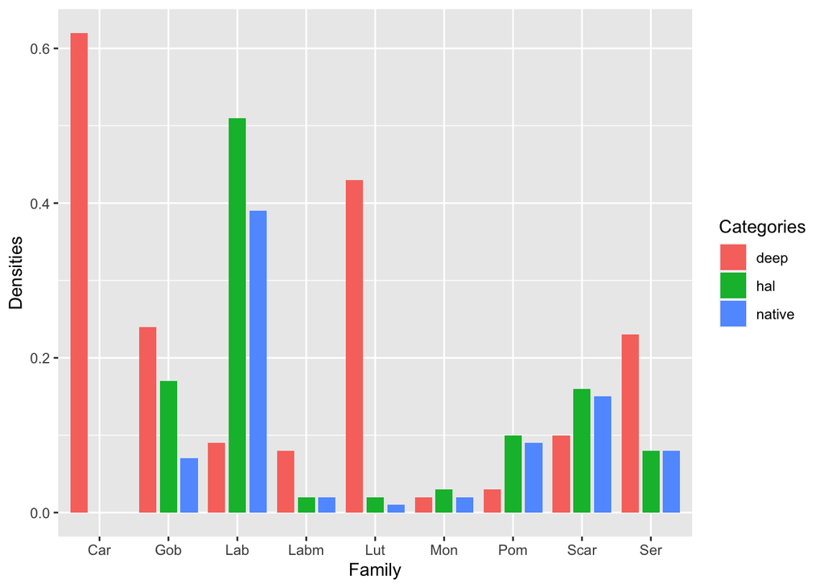

```r
#selected the families contributing to 90% of the differences between all groups, then determined density of each family, by taking the total count of each family divided by 100 (square meters) which is the area of the transects
  fishdens<-fishdens%>%select(Transect,
                              Labridae,
                              Lutjanidae,
                              Gobiidae,
                              Serranidae,
                              Scaridae,
                              Labrisomidae,
                              Carangidae,
                              Pomacentridae,
                              Monacanthidae )%>%
    mutate("Lab"=Labridae/100,
                                  "Lut"=Lutjanidae/100,
                                  "Gob"=Gobiidae/100,
                                  "Ser"=Serranidae/100,
                                  "Scar"=Scaridae/100,
                                  "Labm"=Labrisomidae/100,
                                  "Car"=Carangidae/100,
                                  "Pom"=Pomacentridae/100,
                                  "Mon"=Monacanthidae/100)



#now merge the two dataframes, so we know the categories and the densities
fgmerge<-merge(fishdens, grass[,c("Transect", "dhcat")], by="Transect")

#select columns we want to plot the data, transect, all the densities and the category
plotframe <- fgmerge%>%select(Transect,
                              Lab,
                              Lut,
                              Gob,
                              Ser,
                              Scar,
                              Labm,
                              Car,
                              Pom,
                              Mon,
                              dhcat)

#now pivot dataframe longer, for plotting, and make the category a factor
plotframe <- plotframe%>%
  pivot_longer(cols = Lab:Mon,
               names_to = "Family",
               values_to = "density")%>%
  mutate(dhcat = as.factor(dhcat))

#visualize the differences between the families
FNativeVsNonPlot <- ggplot(data = plotframe, aes(x = Family, y = density, fill = dhcat))+
  geom_col(position = position_dodge(0.9), width = 0.75)+
  labs(x = "Family", y = "Densities", fill = "Categories")

FNativeVsNonPlot
```

Visualization looks like there would be significant differences, so test for significant differences between the categories, transformations were attempted to normalize data, unsuccessful, KW tests were run for all density comparisons

First labridae

```r
#load Libraries
library(FSA)#for DunnPost Hoc
```

```r
library(rcompanion)#for cldList function
library(tidyverse)

#we will use the plotframe created in the chunk above for this analysis

#filter for Labridae only
Lab<-plotframe%>%filter(Family=="Lab")

#bartlet test for equal vaiance

bartlett.test(density~dhcat, Lab)
```

```
##
##  Bartlett test of homogeneity of variances
##
## data:  density by dhcat
## Bartlett's K-squared = 69.806, df = 2, p-value = 6.948e-16
```

```r
#p-value = 6.948e-16
#tried transforming the data, unsuccessful, too many zeros run non parametric equivalent
kruskal.test(density~dhcat, data=Lab)
```

```
##
##  Kruskal-Wallis rank sum test
##
## data:  density by dhcat
## Kruskal-Wallis chi-squared = 17.592, df = 2, p-value = 0.0001513
```

```r
#   Kruskal-Wallis rank sum test

#data:  density by dhcat
#Kruskal-Wallis chi-squared = 17.592, df = 2, p-value =
#0.0001513

#now we run post hoc analysis
LabDunn=dunnTest(density ~ dhcat,
  data = Lab)

LabDunn
```

```
## Dunn (1964) Kruskal-Wallis multiple comparison
```

```
##   p-values adjusted with the Holm method.
```

```
##      Comparison          Z      P.unadj       P.adj
## 1    deep - hal -3.3737694 0.0007414646 0.001482929
## 2 deep - native -3.5765002 0.0003482251 0.001044675
## 3  hal - native  0.0476598 0.9619873716 0.961987372
```

```r
#     Comparison          Z      P.unadj       P.adj
#1    deep - hal -3.3737694 0.0007414646 0.001482929
#2 deep - native -3.5765002 0.0003482251 0.001044675
#3  hal - native  0.0476598 0.9619873716 0.961987372

#interpret the results of Dunn and turn into letters of significant difference
Lab1 = LabDunn$res

cldList(comparison = Lab1$Comparison,
        p.value    = Lab1$P.adj,
        threshold  = 0.05)
```

```
##    Group Letter MonoLetter
## 1   deep      a         a
## 2    hal      b          b
## 3 native      b          b
```

```r
#   Group Letter MonoLetter
#1   deep      a         a
#2    hal      b          b
#3 native      b          b

LabSigs<-c("a","b","b")
```

Gobidae

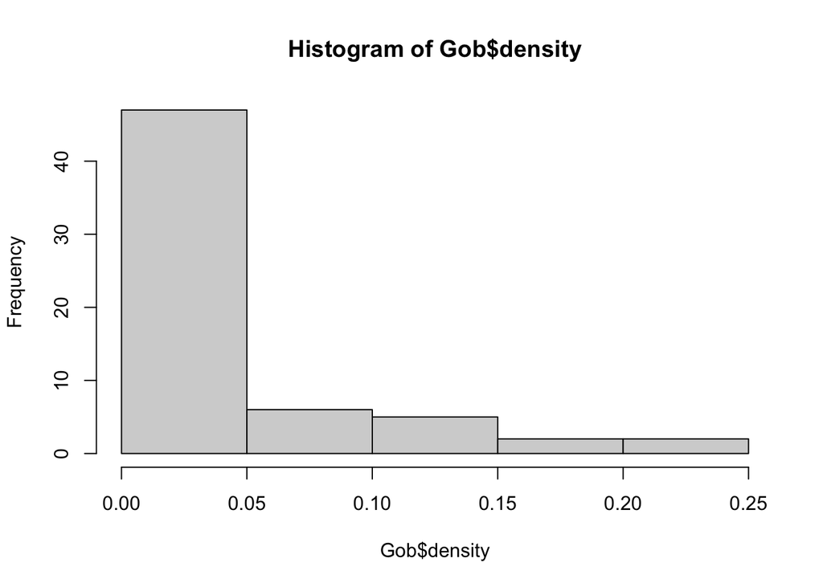

```r
#filter for Gob only
Gob<-plotframe%>%filter(Family=="Gob")


hist(Gob$density)
```

```r
#bartlet test for equal vaiance

bartlett.test(density~dhcat, Gob)
```

```
##
##  Bartlett test of homogeneity of variances
##
## data:  density by dhcat
## Bartlett's K-squared = 19.78, df = 2, p-value = 5.067e-05
```

```r
#p-value = 5.067e-05, fail bartlet test

# too many zeros run non parametric equivalent

kruskal.test(density~dhcat, data=Gob)
```

```
##
##  Kruskal-Wallis rank sum test
##
## data:  density by dhcat
## Kruskal-Wallis chi-squared = 8.5397, df = 2, p-value = 0.01398
```

```r
#   Kruskal-Wallis rank sum test

#data:  density by dhcat
#Kruskal-Wallis chi-squared = 8.5397, df = 2, p-value = 0.01398


#now we run post hoc analysis
GobDunn=dunnTest(density ~ dhcat,
  data = Gob)

GobDunn
```

```
## Dunn (1964) Kruskal-Wallis multiple comparison
```

```
##   p-values adjusted with the Holm method.
```

```
##      Comparison         Z    P.unadj      P.adj
## 1    deep - hal 0.1243478 0.90103987 0.90103987
## 2 deep - native 2.7526420 0.00591165 0.01773495
## 3  hal - native 2.2535917 0.02422187 0.04844373
```

```r
#     Comparison         Z    P.unadj      P.adj
#1    deep - hal 0.1243478 0.90103987 0.90103987
#2 deep - native 2.7526420 0.00591165 0.01773495
#3  hal - native 2.2535917 0.02422187 0.04844373

Gob1 = GobDunn$res

cldList(comparison = Gob1$Comparison,
        p.value    = Gob1$P.adj,
        threshold  = 0.05)
```

```
##    Group Letter MonoLetter
## 1   deep      a         a
## 2    hal      a         a
## 3 native      b          b
```

```r
#  Group Letter MonoLetter
#1     1      a         a
#2     2      a         a
#3     3      b          b

GobSigs<-c("a", "a", "b")
```

Lutjanidae

```r
View(plotframe)

#filter for Lut only
Lut<-plotframe%>%filter(Family=="Lut")

#bartlet test for equal vaiance

bartlett.test(density~dhcat, Lut)
```

```
##
##  Bartlett test of homogeneity of variances
##
## data:  density by dhcat
## Bartlett's K-squared = 168.46, df = 2, p-value < 2.2e-16
```

```r
#p-value < 2.2e-16

# too many zeros run non parametric equivalent

kruskal.test(density~dhcat, data=Lut)
```

```
##
##  Kruskal-Wallis rank sum test
##
## data:  density by dhcat
## Kruskal-Wallis chi-squared = 20.804, df = 2, p-value = 3.038e-05
```

```r
#   Kruskal-Wallis rank sum test

#data:  density by dhcat
#Kruskal-Wallis chi-squared = 20.804, df = 2, p-value =
#3.038e-05

#now we run post hoc analysis
LutDunn=dunnTest(density ~ dhcat,
  data = Lut)

LutDunn
```

```
## Dunn (1964) Kruskal-Wallis multiple comparison
```

```
##   p-values adjusted with the Holm method.
```

```
##      Comparison        Z      P.unadj        P.adj
## 1    deep - hal 2.795159 5.187424e-03 1.037485e-02
## 2 deep - native 4.390115 1.132909e-05 3.398728e-05
## 3  hal - native 1.188514 2.346311e-01 2.346311e-01
```

```r
#     Comparison        Z      P.unadj        P.adj
#1    deep - hal 2.795159 5.187424e-03 1.037485e-02
#2 deep - native 4.390115 1.132909e-05 3.398728e-05
#3  hal - native 1.188514 2.346311e-01 2.346311e-01

Lut1 = LutDunn$res

cldList(comparison = Lut1$Comparison,
        p.value    = Lut1$P.adj,
        threshold  = 0.05)
```

```
##    Group Letter MonoLetter
## 1   deep      a         a
## 2    hal      b          b
## 3 native      b          b
```

```r
#   Group Letter MonoLetter
#1   deep      a         a
#2    hal      b          b
#3 native      b          b

LutSigs<-c("a","b","b")
```

Serranidae

```r
#filter for Ser only
Ser<-plotframe%>%filter(Family=="Ser")

#bartlet test for equal vaiance

bartlett.test(density~dhcat, Ser)
```

```
##
##  Bartlett test of homogeneity of variances
##
## data:  density by dhcat
## Bartlett's K-squared = 14.161, df = 2, p-value = 0.0008415
```

```r
#p-value = 0.0008415

# too many zeros run non parametric equivalent

kruskal.test(density~dhcat, data=Ser)
```

```
##
##  Kruskal-Wallis rank sum test
##
## data:  density by dhcat
## Kruskal-Wallis chi-squared = 11.466, df = 2, p-value = 0.003237
```

```r
#   Kruskal-Wallis rank sum test

#data:  density by dhcat
#Kruskal-Wallis chi-squared = 11.466, df = 2, p-value =
#0.003237

#now we run post hoc analysis
SerDunn=dunnTest(density ~ dhcat,
  data = Ser)

SerDunn
```

```
## Dunn (1964) Kruskal-Wallis multiple comparison
```

```
##   p-values adjusted with the Holm method.
```

```
##      Comparison          Z     P.unadj       P.adj
## 1    deep - hal  2.9840092 0.002844982 0.008534946
## 2 deep - native  2.6040913 0.009211821 0.018423641
## 3  hal - native -0.5233973 0.600697770 0.600697770
```

```r
#     Comparison          Z     P.unadj       P.adj
#1    deep - hal  2.9840092 0.002844982 0.008534946
#2 deep - native  2.6040913 0.009211821 0.018423641
#3  hal - native -0.5233973 0.600697770 0.600697770

Ser1 = SerDunn$res

cldList(comparison = Ser1$Comparison,
        p.value    = Ser1$P.adj,
        threshold  = 0.05)
```

```
##    Group Letter MonoLetter
## 1   deep      a         a
## 2    hal      b          b
## 3 native      b          b
```

```r
#   Group Letter MonoLetter
#1   deep      a         a
#2    hal      b          b
#3 native      b          b

SerSigs<-c("a","b","b")
```

Scaridae

```r
#filter for scar only
Scar<-plotframe%>%filter(Family=="Scar")

#bartlet test for equal vaiance

bartlett.test(density~dhcat, Scar)
```

```
##
##  Bartlett test of homogeneity of variances
##
## data:  density by dhcat
## Bartlett's K-squared = 4.6041, df = 2, p-value = 0.1001
```

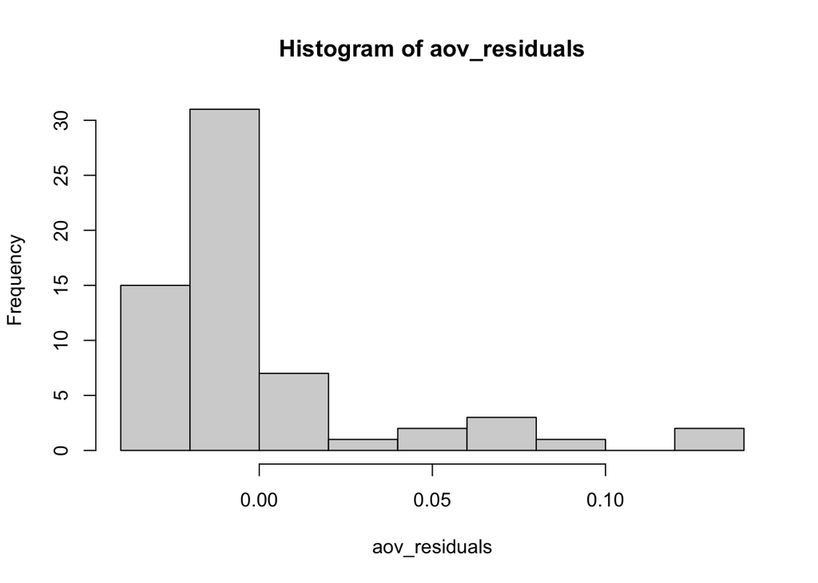

```r
#p-value = 0.1001, significant bartlett, check residuals

ScarANOVA <- aov(density ~ dhcat, data = Scar)

# then we can easily pull them out of the output
aov_residuals <- residuals(ScarANOVA)

# let's first look to see if they look approximately normally distributed
hist(aov_residuals)
```

```r
# then we can test if the residuals are approximately normally distributed with the Shapiro-Wilk Test
shapiro.test(aov_residuals)
```

```
##
##  Shapiro-Wilk normality test
##
## data:  aov_residuals
## W = 0.72476, p-value = 1.824e-09
```

```r
#nope, sad day, nan parametric it is

# too many zeros run non parametric equivalent

kruskal.test(density~dhcat, data=Scar)
```

```
##
##  Kruskal-Wallis rank sum test
##
## data:  density by dhcat
## Kruskal-Wallis chi-squared = 2.0336, df = 2, p-value = 0.3618
```

```r
#   Kruskal-Wallis rank sum test

#data:  density by dhcat
#Kruskal-Wallis chi-squared = 2.0336, df = 2, p-value = 0.3618

#not significant, no post hoc needed
```

Labrisomidae

```r
#filter for Labm only
Labm<-plotframe%>%filter(Family=="Labm")

#bartlet test for equal vaiance

bartlett.test(density~dhcat, Labm)
```

```
##
##  Bartlett test of homogeneity of variances
##
## data:  density by dhcat
## Bartlett's K-squared = 42.136, df = 2, p-value = 7.084e-10
```

```r
#p-value = 7.084e-10

# too many zeros run non parametric equivalent

kruskal.test(density~dhcat, data=Labm)
```

```
##
##  Kruskal-Wallis rank sum test
##
## data:  density by dhcat
## Kruskal-Wallis chi-squared = 6.8654, df = 2, p-value = 0.0323
```

```r
#   Kruskal-Wallis rank sum test

#data:  density by dhcat
#Kruskal-Wallis chi-squared = 6.8654, df = 2, p-value = 0.0323#

#now we run post hoc analysis
LabmDunn=dunnTest(density ~ dhcat,
  data = Labm)

LabmDunn
```

```
## Dunn (1964) Kruskal-Wallis multiple comparison
```

```
##   p-values adjusted with the Holm method.
```

```
##      Comparison         Z    P.unadj      P.adj
## 1    deep - hal 1.7134507 0.08662966 0.17325931
## 2 deep - native 2.4806467 0.01311443 0.03934329
## 3  hal - native 0.5474016 0.58410288 0.58410288
```

```r
#     Comparison         Z    P.unadj      P.adj
#1    deep - hal 1.7134507 0.08662966 0.17325931
#2 deep - native 2.4806467 0.01311443 0.03934329
#3  hal - native 0.5474016 0.58410288 0.58410288

Labm1 = LabmDunn$res

cldList(comparison = Labm1$Comparison,
        p.value    = Labm1$P.adj,
        threshold  = 0.05)
```

```
##    Group Letter MonoLetter
## 1   deep      a         a
## 2    hal     ab         ab
## 3 native      b          b
```

```r
#   Group Letter MonoLetter
#1   deep      a         a
#2    hal     ab         ab
#3 native      b          b

LabmSigs<-c("a", "ab", "b")
```

Carringidae

```r
#filter for car only
Car<-plotframe%>%filter(Family=="Car")

#bartlet test for equal vaiance

bartlett.test(density~dhcat, Car)
```

```
##
##  Bartlett test of homogeneity of variances
##
## data:  density by dhcat
## Bartlett's K-squared = Inf, df = 2, p-value < 2.2e-16
```

```r
#-value < 2.2e-16

# too many zeros run non parametric equivalent

kruskal.test(density~dhcat, data=Car)
```

```
##
##  Kruskal-Wallis rank sum test
##
## data:  density by dhcat
## Kruskal-Wallis chi-squared = 5.1013, df = 2, p-value = 0.07803
```

```r
#Kruskal-Wallis rank sum test

#data:  density by dhcat
#Kruskal-Wallis chi-squared = 5.1013, df = 2, p-value = 0.07803

#not significant
```

Pomocentridae

```r
#filter for Pom only
Pom<-plotframe%>%filter(Family=="Pom")

#bartlet test for equal vaiance

bartlett.test(density~dhcat, Pom)
```

```
##
##  Bartlett test of homogeneity of variances
##
## data:  density by dhcat
## Bartlett's K-squared = 44.96, df = 2, p-value = 1.726e-10
```

```r
# p-value = 1.726e-10

# too many zeros run non parametric equivalent

kruskal.test(density~dhcat, data=Pom)
```

```
##
##  Kruskal-Wallis rank sum test
##
## data:  density by dhcat
## Kruskal-Wallis chi-squared = 5.1612, df = 2, p-value = 0.07573
```

```r
#   Kruskal-Wallis rank sum test

#data:  density by dhcat
#Kruskal-Wallis chi-squared = 5.1612, df = 2, p-value = 0.07573

#not signicant
```

Monocanthidae

```r
#filter for Mon only
Mon<-plotframe%>%filter(Family=="Mon")

#bartlet test for equal vaiance

bartlett.test(density~dhcat, Mon)
```

```
##
##  Bartlett test of homogeneity of variances
##
## data:  density by dhcat
## Bartlett's K-squared = 6.5116, df = 2, p-value = 0.03855
```

```r
#-value = 0.03855

# too many zeros run non parametric equivalent

kruskal.test(density~dhcat, data=Mon)
```

```
##
##  Kruskal-Wallis rank sum test
##
## data:  density by dhcat
## Kruskal-Wallis chi-squared = 3.6407, df = 2, p-value = 0.162
```

```r
#Kruskal-Wallis rank sum test

#data:  density by dhcat
#Kruskal-Wallis chi-squared = 3.6407, df = 2, p-value = 0.162
#no significant difference
```

```r
library(readr)
library(tidyverse)
library(vegan)
```

```r
library(FSA)#for DunnPost Hoc
library(rcompanion)#for cldList function\
library(patchwork)#to combine plots

AllMerged<- read_csv("AllMerged.csv")
#total count of each type of fish on each transect, select for snappers, then calculate density
snap<-AllMerged %>%
  group_by(Transect)%>%
  count(Common.Names)%>%
  pivot_wider(names_from = Common.Names , values_from = n)%>%
   select("Transect",
          "Yellowtail Snapper",
          "Lane Snapper",
          "Cubera Snapper")%>%mutate(ysdens=`Yellowtail Snapper`/100,
                                     lsdens=`Lane Snapper`/100,
                                     csdens=`Cubera Snapper`/100)%>%
  select(Transect,
         ysdens,
         lsdens,
         csdens)

##Turning NAs to 0s
snap[is.na(snap)] <- 0


#pivot longer for analysis/plotting
snap<-snap%>%
  pivot_longer(cols = ysdens:csdens,
               names_to = "Species",
               values_to = "density")

#importing the information for categories
categories<- read_csv("Data/WeFixedItAnalyzeMe.csv")
```

```
## ──────────────────────────────────────────────────────── Delimiter: "," chr
## (1): Transect dbl (15): ...1, N, Species_Richness, simpsons, depth,
## PCovHalophila, PCovMac...
```

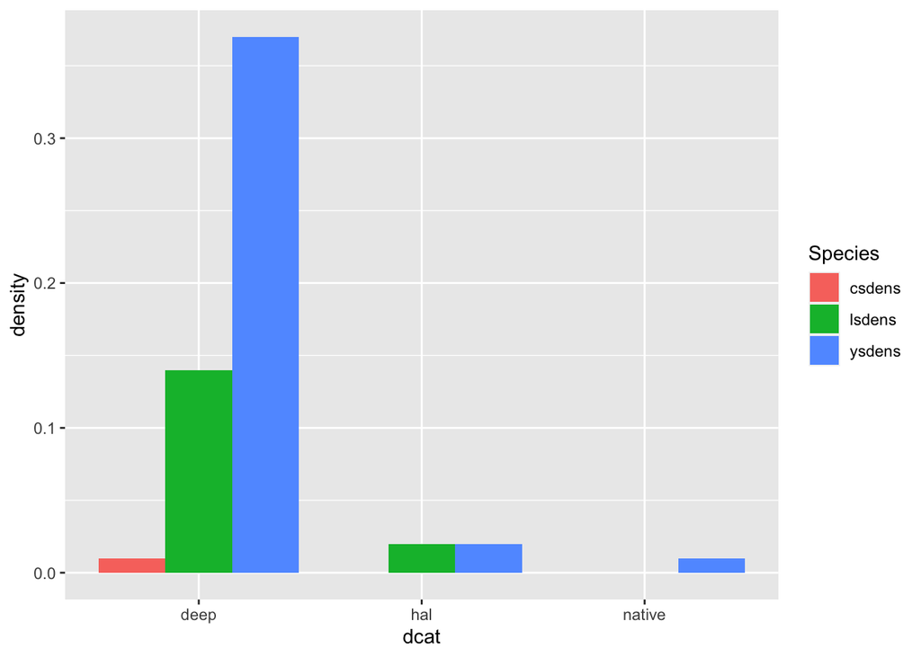

```r
grass<-categories %>%
  mutate(totalgrass= (PCovHalophila+
                        PCovThalassia+
                        PCovHalodule+
                        PCovSyringodium)) %>%
  mutate(PerHalTotal=(PCovHalophila/totalgrass))

##Making the NAs 0
grass[is.na(grass)] <- 0


##Make a category column##
 grass <- grass %>%
       mutate(dcat = case_when((depth >= 15.0) ~ "deep",
                                (depth <= 15.0 & PerHalTotal == 1.0) ~ "hal",
                                (depth <= 15.0 & PerHalTotal < 1.0) ~ "native" ))%>%
   select(Transect, dcat)

#now we merge with our fish info, so we have cat info
snapsbro<- merge(grass, snap, by= "Transect")


#plot to get an idea of trends
snapsbroplot<-snapsbro%>%ggplot(aes(x=dcat, y= density, fill= Species))+
  geom_bar(stat="identity", position=position_dodge())

snapsbroplot
```

```r
#filter for species to ensure the trends are the same as Lut KW from above
snapsbroy<-snapsbro %>% filter(Species == "ysdens")
kruskal.test(snapsbroy$density ~ snapsbroy$dcat, data = snapsbroy)
```

```
##
##  Kruskal-Wallis rank sum test
##
## data:  snapsbroy$density by snapsbroy$dcat
## Kruskal-Wallis chi-squared = 20.29, df = 2, p-value = 3.927e-05
```

```r
 # Kruskal-Wallis rank sum test

#data:  snapsbroy$density by snapsbroy$dcat
#Kruskal-Wallis chi-squared = 20.29, df = 2, p-value =
#3.927e-05

#now we run post hoc analysis
YTDunn=dunnTest(density ~ dcat,
  data = snapsbroy)
YTDunn
```

```
## Dunn (1964) Kruskal-Wallis multiple comparison
##   p-values adjusted with the Holm method.
```

```
##      Comparison         Z      P.unadj        P.adj
## 1    deep - hal 3.1544823 1.607831e-03 3.215663e-03
## 2 deep - native 4.1647363 3.117127e-05 9.351381e-05
## 3  hal - native 0.6616915 5.081689e-01 5.081689e-01
```

```r
#     Comparison         Z      P.unadj        P.adj
#1    deep - hal 3.1544823 1.607831e-03 3.215663e-03
#2 deep - native 4.1647363 3.117127e-05 9.351381e-05
#3  hal - native 0.6616915 5.081689e-01 5.081689e-01

YT1 = YTDunn$res

cldList(comparison = YT1$Comparison,
        p.value    = YT1$P.adj,
        threshold  = 0.05)
```

```
##    Group Letter MonoLetter
## 1   deep      a         a
## 2    hal      b          b
## 3 native      b          b
```

```r
#  Group Letter MonoLetter
#1   deep      a         a
#2    hal      b          b
#3 native      b          b

#YT is same as all snappers

snapsbrol<-snapsbro%>%filter(Species=="lsdens")
kruskal.test(snapsbrol$density ~ snapsbrol$dcat, data = snapsbrol)
```

```
##
##  Kruskal-Wallis rank sum test
##
## data:  snapsbrol$density by snapsbrol$dcat
## Kruskal-Wallis chi-squared = 10.074, df = 2, p-value = 0.006492
```

```r
#   Kruskal-Wallis rank sum test

#data:  snapsbrol$density by snapsbrol$dcat
#Kruskal-Wallis chi-squared = 10.074, df = 2, p-value =
#0.006492

#now we run post hoc analysis
LSDunn=dunnTest(density ~ dcat,
  data = snapsbrol)
LSDunn
```

```
## Dunn (1964) Kruskal-Wallis multiple comparison
##   p-values adjusted with the Holm method.
```

```
##      Comparison         Z     P.unadj       P.adj
## 1    deep - hal 1.9234019 0.054429594 0.108859188
## 2 deep - native 3.0623587 0.002196001 0.006588004
## 3  hal - native 0.8534977 0.393383377 0.393383377
```

```r
#     Comparison         Z     P.unadj       P.adj
#1    deep - hal 1.9234019 0.054429594 0.108859188
#2 deep - native 3.0623587 0.002196001 0.006588004
#3  hal - native 0.8534977 0.393383377 0.393383377

LS1 = LSDunn$res

cldList(comparison = LS1$Comparison,
        p.value    = LS1$P.adj,
        threshold  = 0.05)
```

```
##    Group Letter MonoLetter
## 1   deep      a         a
## 2    hal     ab         ab
## 3 native      b          b
```

```r
#   Group Letter MonoLetter
#1   deep      a         a
#2    hal     ab         ab
#3 native      b          b

snapsbroc<-snapsbro%>%filter(Species=="csdens")
kruskal.test(snapsbroc$density ~ snapsbroc$dcat, data = snapsbroc)
```

```
##
##  Kruskal-Wallis rank sum test
##
## data:  snapsbroc$density by snapsbroc$dcat
## Kruskal-Wallis chi-squared = 1.2143, df = 2, p-value = 0.5449
```

```r
#Kruskal-Wallis rank sum test

#data:  snapsbroc$density by snapsbroc$dcat
#Kruskal-Wallis chi-squared = 1.2143, df = 2, p-value = 0.5449

#cs, not significantly different among categories
```

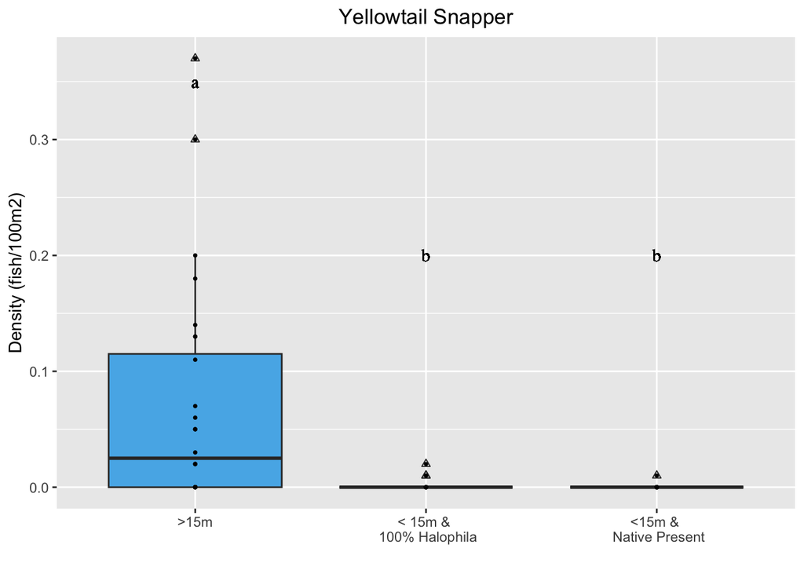

```r
#and now we plot!

#get yellowtail boxplot working, look how we want it

YT<-snapsbro%>%
    filter(Species=="ysdens")%>%
    ggplot(names=labels, aes(x=dcat, y=density, fill=dcat))+
  geom_boxplot(outlier.shape=2)+#change the shape of outliers
  geom_point(size=0.6)+#adds the points onto plot in single line
  xlab(" ")+#no x axis labels
  ylab("Density (fish/100m2)")+
  ggtitle("Yellowtail Snapper")+
  theme(plot.title = element_text(hjust = 0.5))+#how to center the title
  scale_fill_manual(name = "Category", labels = c(">15m", "< 15m & 100% Halophila","< 15m & Native Present"),values = c("#56B4E9","#F0E442","#CC79A7"))+#pick the colors
  scale_x_discrete(labels=c(">15m", "< 15m & \n 100% Halophila","<15m & \n Native Present"))+geom_text(aes(family="serif", fontface="plain"),x= "deep" , y=0.35, label="a")+#add first letter, family and fontface change font and remove bold
  geom_text(aes(family="serif", fontface="plain"),x= "hal" , y=0.2, label="b")+#add second letter
  geom_text(aes(family="serif", fontface="plain"), x= "native" , y=0.2, label="b")+#add third letter
  theme(legend.position="none")#removes legend


YT
```

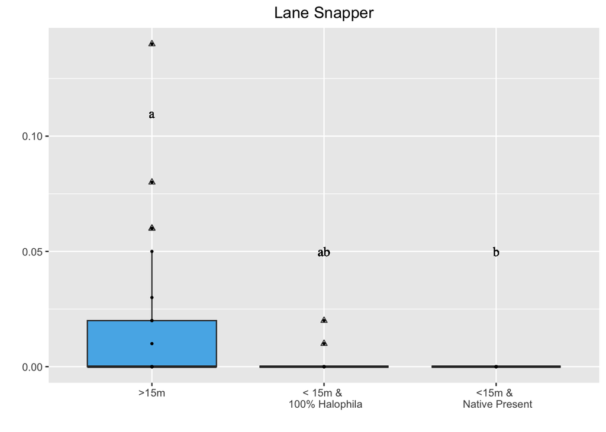

```r
#lane snapper
LS<-snapsbro%>%
    filter(Species=="lsdens")%>%
    ggplot(names=labels, aes(x=dcat, y=density, fill=dcat))+
  geom_boxplot(outlier.shape=2)+#change the shape of outliers
  geom_point(size=0.6)+#adds the points onto plot in single line
  xlab(" ")+#no x axis labels
  ylab(" ")+
  ggtitle("Lane Snapper")+
  theme(plot.title = element_text(hjust = 0.5))+#how to center the title
  scale_fill_manual(name = "Category", labels = c(">15m", "< 15m & 100% Halophila","< 15m & Native Present"),values = c("#56B4E9","#F0E442","#CC79A7"))+#pick the colors
  scale_x_discrete(labels=c(">15m", "< 15m & \n 100% Halophila","<15m & \n Native Present"))+geom_text(aes(family="serif", fontface="plain"),x= "deep" , y=0.11, label="a")+#add first letter, family and fontface change font and remove bold
  geom_text(aes(family="serif", fontface="plain"),x= "hal" , y=0.05, label="ab")+#add second letter
  geom_text(aes(family="serif", fontface="plain"), x= "native" , y=0.05, label="b")+#add third letter
  theme(legend.position="none")#removes legend


LS
```

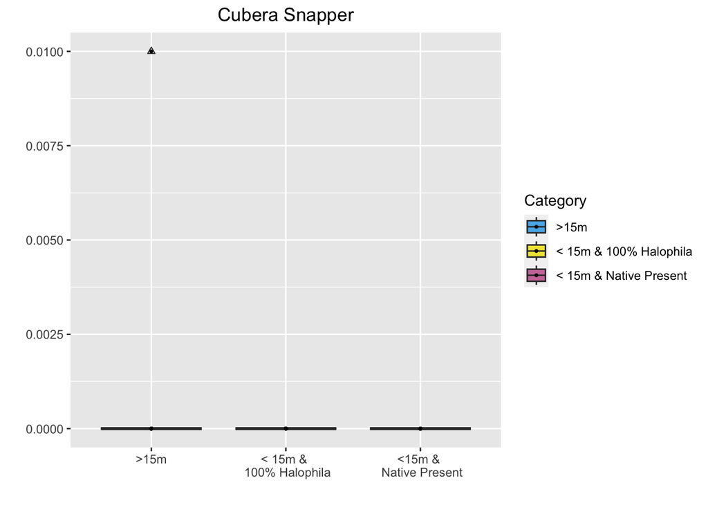

```r
#Cubera Snapper
CS<-snapsbro%>%
    filter(Species=="csdens")%>%
    ggplot(names=labels, aes(x=dcat, y=density, fill=dcat))+
  geom_boxplot(outlier.shape=2)+#change the shape of outliers
  geom_point(size=0.6)+#adds the points onto plot in single line
  xlab(" ")+#no x axis labels
  ylab(" ")+#no y axis label
  ggtitle("Cubera Snapper")+
  theme(plot.title = element_text(hjust = 0.5))+#how to center the title
  scale_fill_manual(name = "Category", labels = c(">15m", "< 15m & 100% Halophila","< 15m & Native Present"),values = c("#56B4E9","#F0E442","#CC79A7"))+#pick the colors
  scale_x_discrete(labels=c(">15m", "< 15m & \n 100% Halophila","<15m & \n Native Present"))

CS
```

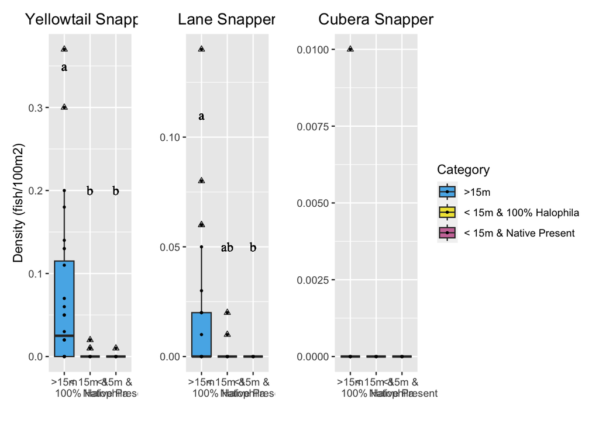

```r
#combine all three plots
snap<-YT+LS+CS
snap
```

### Seagrass

Ok, so we decided that instead of using the linear analyses we are going to use a categorical test, to test for differences in info for the three categories, so we are going to look at

1. Species Richness
2. Simpsons Index of Diversity

Across the three seagrass categories 1. >15m 2. <15m, 100% Halophila 3. <15m, native present

```r
#csvs needed
finalanalyze1 <- read.csv("Data/WeFixedItAnalyzeMe.csv")

#libraries
library(tidyverse)
library(agricolae)#Tukey post hoc test
```

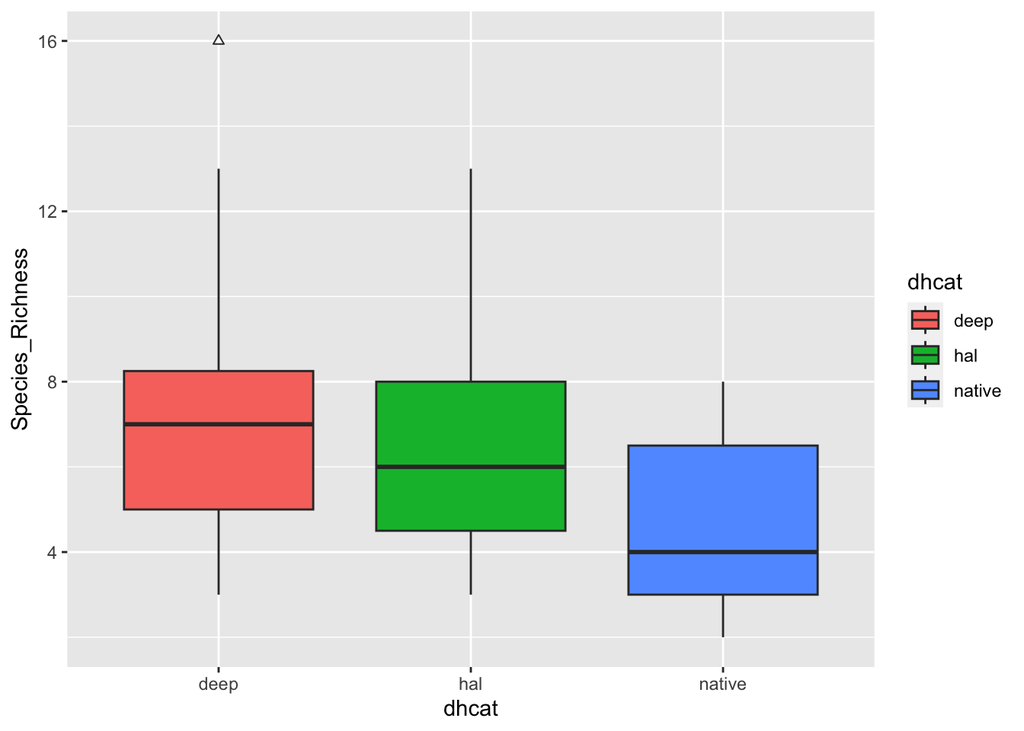

```r
#add our seagrass categories to the dataframe
finalanalyze1<-finalanalyze1 %>%
  mutate(totalgrass= (finalanalyze1$PCovHalophila+
                      finalanalyze1$PCovThalassia+
                      finalanalyze1$PCovHalodule+
                      finalanalyze1$PCovSyringodium)) %>%
  mutate(PerHalTotal=(finalanalyze1$PCovHalophila/totalgrass))

##Nas were generated on three transects where there was no seagrass, because cannot divide by zero, Making the NAs 0
finalanalyze1[is.na(finalanalyze1)] <- 0

##Make the depth bin categories, we know that deeper than 15 meters there is no native seagrasses, and we want to separate the transects below 15 meters into two groups, ones that are 100% halophila, and ones that are not 100% halophila and contain native seagrasses, and then select for column that we need for further analysis
finalanalyze1<- finalanalyze1%>%
       mutate(dhcat = case_when((depth >= 15.0) ~ "deep",
                                (depth <= 15.0 & PerHalTotal == 1.0) ~ "hal",
                                (depth <= 15.0 & PerHalTotal < 1.0) ~ "native" ))%>%
  select(Transect, dhcat, Species_Richness, simpsons)


#Species Richness
#visualize the data

Richness<-finalanalyze1%>%
    ggplot(names=labels, aes(x=dhcat, y=Species_Richness, fill=dhcat))+
  geom_boxplot(outlier.shape=2)


Richness
```

```r
#check anova assumptions

#equal variance, bartlet test
bartlett.test(Species_Richness~dhcat, finalanalyze1)
```

```
##
##  Bartlett test of homogeneity of variances
##
## data:  Species_Richness by dhcat
## Bartlett's K-squared = 2.9604, df = 2, p-value = 0.2276
```

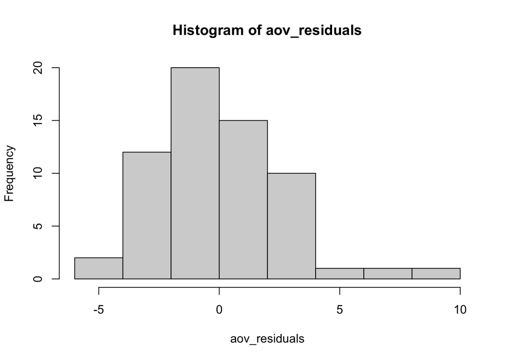

```r
#Bartlett test of homogeneity of variances

#data:  Species_Richness by dhcat
#Bartlett's K-squared = 2.9604, df = 2, p-value = 0.2276
#we have equal variance, on to the next assumption

#run the ANOVA to check the residuals
RichnessANOVA <- aov(Species_Richness ~ dhcat, data = finalanalyze1)

# then we can easily pull them out of the output
aov_residuals <- residuals(RichnessANOVA)

hist(aov_residuals)#looks pretty good
```

```r
shapiro.test(aov_residuals)
```

```
##
##  Shapiro-Wilk normality test
##
## data:  aov_residuals
## W = 0.94989, p-value = 0.01318
```

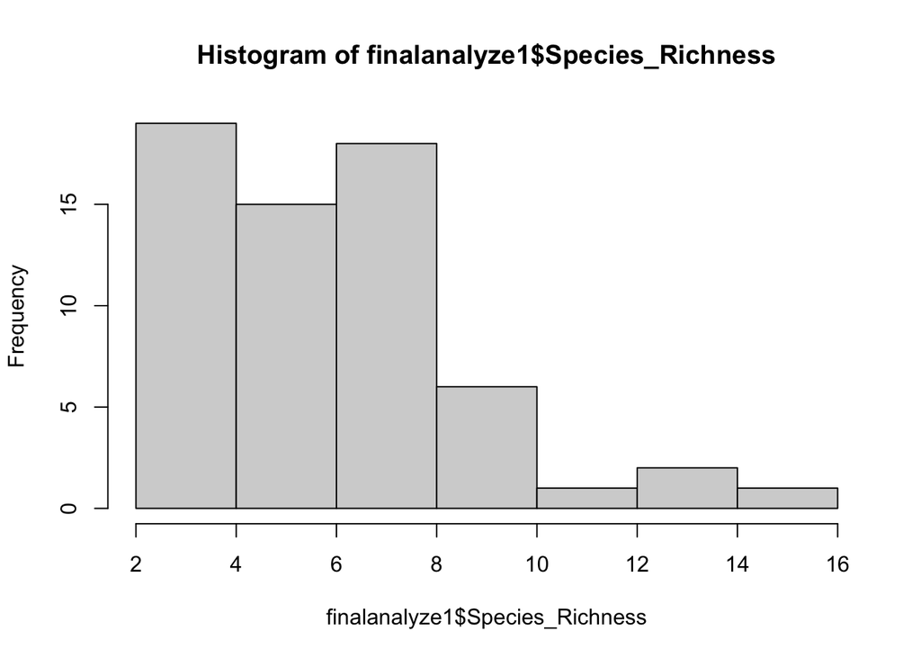

```r
#Shapiro-Wilk normality test

#data:  aov_residuals
#W = 0.94989, p-value = 0.01318
#not normally distributed sad day, try transormation

finalanalyze1$rsqrt<-(sqrt(finalanalyze1$Species_Richness))
hist(finalanalyze1$Species_Richness)
```

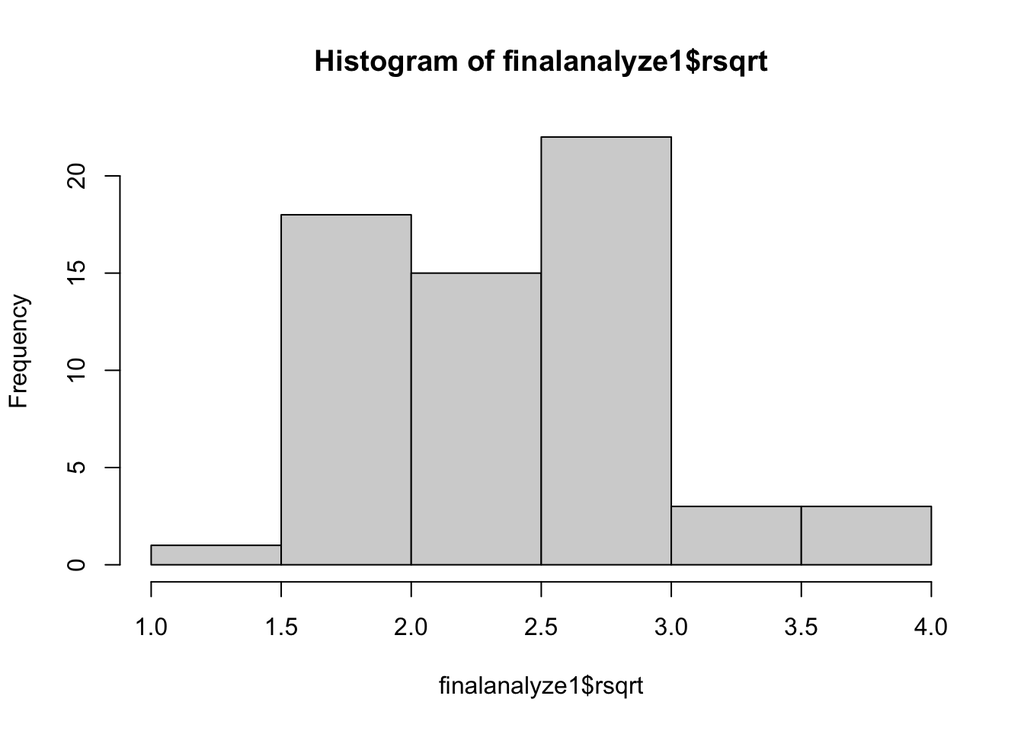

```r
hist(finalanalyze1$rsqrt)
```

```r
#check assumpitons of transformed data
bartlett.test(rsqrt~dhcat, finalanalyze1)
```

```
##
##  Bartlett test of homogeneity of variances
##
## data:  rsqrt by dhcat
## Bartlett's K-squared = 0.75413, df = 2, p-value = 0.6859
```

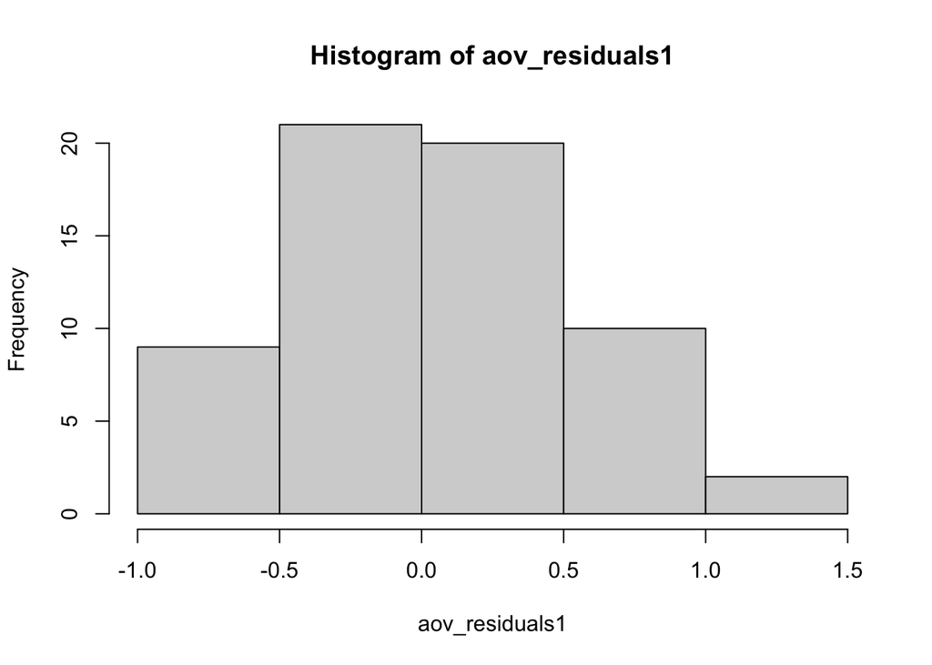

```r
#   Bartlett test of homogeneity of variances

#data:  rsqrt by dhcat
#Bartlett's K-squared = 0.75413, df = 2, p-value = 0.6859

#run the ANOVA to check the residuals
RichnessANOVAsr <- aov(rsqrt ~ dhcat, data = finalanalyze1)
aov_residuals1 <- residuals(RichnessANOVAsr)
hist(aov_residuals1)
```

```r
shapiro.test(aov_residuals1)
```

```
##
##  Shapiro-Wilk normality test
##
## data:  aov_residuals1
## W = 0.97635, p-value = 0.2745
```

```r
#   Shapiro-Wilk normality test

#data:  aov_residuals1
#W = 0.97635, p-value = 0.2745
#transformation worked!!! I can run an ANOVA!!!


summary(RichnessANOVAsr)
```

```
##             Df Sum Sq Mean Sq F value Pr(>F)
## dhcat        2  2.347  1.1734   4.324 0.0177 *
## Residuals   59 16.011  0.2714
## ---
## Signif. codes:  0 '***' 0.001 '**' 0.01 '*' 0.05 '.' 0.1 ' ' 1
```

```r
#            Df Sum Sq Mean Sq F value Pr(>F)
#dhcat        2  2.347  1.1734   4.324 0.0177 *
#Residuals   59 16.011  0.2714
#---
#Signif. codes:  0 ‘***’ 0.001 ‘**’ 0.01 ‘*’ 0.05 ‘.’ 0.1 ‘ ’ 1

Tukey <- HSD.test(RichnessANOVAsr, "dhcat")
Tukey
```

```
## $statistics
##     MSerror Df     Mean      CV
##   0.2713647 59 2.458175 21.1916
##
## $parameters
##    test name.t ntr StudentizedRange alpha
##   Tukey  dhcat   3         3.400118  0.05
##
## $means
##           rsqrt       std  r      Min      Max      Q25      Q50      Q75
## deep   2.633168 0.5395429 28 1.732051 4.000000 2.236068 2.645751 2.871320
## hal    2.484874 0.5594027 15 1.732051 3.605551 2.118034 2.449490 2.828427
## native 2.179213 0.4576268 19 1.414214 2.828427 1.732051 2.000000 2.547621
##
## $comparison
## NULL
##
## $groups
##           rsqrt groups
## deep   2.633168      a
## hal    2.484874     ab
## native 2.179213      b
##
## attr(,"class")
## [1] "group"
```

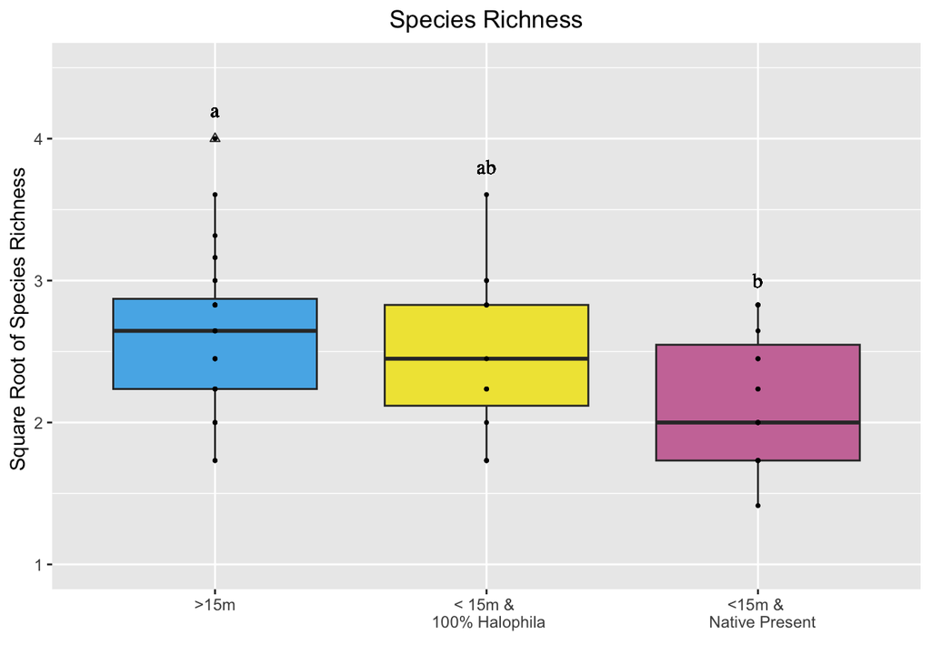

```r
#$statistics
#    MSerror Df     Mean      CV
#  0.2713647 59 2.458175 21.1916

#$parameters
#   test name.t ntr StudentizedRange alpha
#  Tukey  dhcat   3         3.400118  0.05

#$means
#          rsqrt       std  r      Min      Max      Q25      Q50      Q75
#deep   2.633168 0.5395429 28 1.732051 4.000000 2.236068 2.645751 2.871320
#hal    2.484874 0.5594027 15 1.732051 3.605551 2.118034 2.449490 2.828427
#native 2.179213 0.4576268 19 1.414214 2.828427 1.732051 2.000000 2.547621

#$comparison
#NULL

#$groups
#          rsqrt groups
#deep   2.633168      a
#hal    2.484874     ab
#native 2.179213      b

#attr(,"class")
#[1] "group"

RichnessFinal<-finalanalyze1%>%
    ggplot(names=labels, aes(x=dhcat, y=rsqrt, fill=dhcat))+
  geom_boxplot(outlier.shape=2)+#change the shape of outliers
  geom_point(size=0.6)+#adds the points onto plot in single line
  xlab(" ")+#no x axis labels
  ylab("Square Root of Species Richness ")+#no y axis lables
  ggtitle("Species Richness")+
  theme(plot.title = element_text(hjust = 0.5))+#how to center the title
  scale_fill_manual(name = "Category", labels = c(">15m", "< 15m & 100% Halophila","< 15m & Native Present"),values = c("#56B4E9","#F0E442","#CC79A7"))+#pick the colors
  scale_x_discrete(labels=c(">15m", "< 15m & \n 100% Halophila","<15m & \n  Native Present"))+geom_text(aes(family="serif", fontface="plain"),x= "deep" , y=4.2, label="a")+#add first letter, family and fontface change font and remove bold
  geom_text(aes(family="serif", fontface="plain"),x= "hal" , y=3.8, label="ab")+#add second letter
  geom_text(aes(family="serif", fontface="plain"), x= "native" , y=3, label="b")+#add third letter
  theme(legend.position="none")+#removes legend
    ylim(1,4.5)#manually set y axis #removes legend


RichnessFinal
```

Now looking at the effect of categories on Simpsons index of diversity

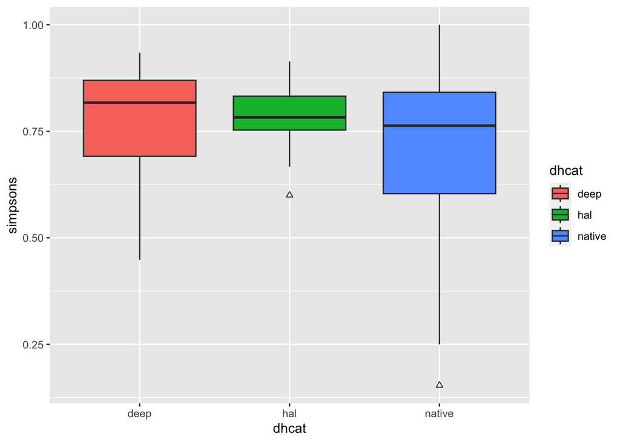

```r
#csvs needed
finalanalyze1 <- read.csv("Data/WeFixedItAnalyzeMe.csv")

#libraries
library(tidyverse)
library(agricolae)#Tukey post hoc test

#add our seagrass categories to the dataframe
finalanalyze1<-finalanalyze1 %>%
  mutate(totalgrass= (finalanalyze1$PCovHalophila+
                      finalanalyze1$PCovThalassia+
                      finalanalyze1$PCovHalodule+
                      finalanalyze1$PCovSyringodium)) %>%
  mutate(PerHalTotal=(finalanalyze1$PCovHalophila/totalgrass))

##Nas were generated on three transects where there was no seagrass, because cannot divide by zero, Making the NAs 0
finalanalyze1[is.na(finalanalyze1)] <- 0

##Make the depth bin categories, we know that deeper than 15 meters there is no native seagrasses, and we want to separate the transects below 15 meters into two groups, ones that are 100% halophila, and ones that are not 100% halophila and contain native seagrasses, and then select for column that we need for further analysis
finalanalyze1<- finalanalyze1%>%
       mutate(dhcat = case_when((depth >= 15.0) ~ "deep",
                                (depth <= 15.0 & PerHalTotal == 1.0) ~ "hal",
                                (depth <= 15.0 & PerHalTotal < 1.0) ~ "native" ))%>%
  select(Transect, dhcat, Species_Richness, simpsons)


#simpsons
#visualize the data

Simpsons<-finalanalyze1%>%
    ggplot(names=labels, aes(x=dhcat, y=simpsons, fill=dhcat))+
  geom_boxplot(outlier.shape=2)


Simpsons
```